# Portfoliomanagement and Financial Analysis - Assignment 4

Submit until Monday 2019-10-07, 13:00

Markovic, Mitschel

```r
pacman::p_load(tidyverse,tidyquant,PortfolioAnalytics,nloptr)
```

**Please** remember to put your assignment solutions in `rmd` format using **many** chunks and putting readable text in between, similar to my examples given in Research Methods and Assignment 1! Also, each student has to select his own set of 10 stocks having data available as of `2000-01-01`. Select by Sharpe-ratio, dominance or any other method (e.g. matching your first name).

For all exercises: Please use the Assignment-Forum to post your questions, I will try my best to help you along!

```r
library(timetk)
SP500 <- tq_index("SP500")
NASDAQ <- tq_exchange("NASDAQ")
NYSE <- tq_exchange("NYSE")

stocks.selection <- SP500 %>%
 inner_join(rbind(NYSE,NASDAQ) %>%
select(symbol,last.sale.price,market.cap,ipo.year),by=c("symbol")) %>%
 filter(ipo.year<2000&!is.na(market.cap)) %>%
 arrange(desc(weight)) %>%
 slice(1:10)

stocks.selection
```

[output not shown]

These are the returns of the selected stocks.

```r
stocks.returns <- stocks.selection$symbol %>%
tq_get(get = "stock.prices", from = "2000-01-01",
to = "2019-12-31") %>%
group_by(symbol) %>% tq_transmute(select = adjusted,
mutate_fun = periodReturn, period = "monthly")
stocks.returns
```

Stock returns as time series

```r
stocks.returns.xts <- stocks.returns%>%
subset( select = c(symbol,date, monthly.returns)) %>%
pivot_wider(names_from = symbol, values_from = monthly.returns) %>%
tk_xts(date_var = date, silent = TRUE)
stocks.returns.xts
```

## Exercise 1: Rebalancing

Have a look at `vignette("ROI_vignette")` and the `optimize.portfolio.rebalancing` command. Use your dataset to compute

1. Mean-Return (tangency portfolio)

Create portfolio object, add constraints, add objective

```r
portf_maxret <- portfolio.spec(assets=stocks.selection$symbol)%>%
  add.constraint(type="full_investment") %>%
  add.constraint(type="long_only") %>%
  add.objective(type="return", name="mean")

portf_maxret
```

Run the optimization

```r
opt_maxret <- optimize.portfolio(R=stocks.returns.xts, portfolio=portf_maxret,
                  optimize_method="ROI", trace=TRUE)
```

[output not shown]

```r
plot(opt_maxret, chart.assets=TRUE, main="Maximum Return",
  xlim=c(0.05, 0.35), ylim=c(0,0.04))
```

[output not shown]

```r
chart.RiskReward(opt_maxret,return.col="mean", risk.col="sd",
                 chart.assets=TRUE,
                 xlim=c(0.05, 0.25),
                 main="Maximum Return")
```

[output not shown]

```r
maxret.ef <- create.EfficientFrontier(R=stocks.returns.xts,
                                      portfolio=portf_maxret,
                                      type="mean-StdDev")
```

[output not shown]

Backtesting: Quarterly rebalancing with 5 year training period

```r
bt_maxret <-
optimize.portfolio.rebalancing(R=stocks.returns.xts,
                               portfolio=portf_maxret, optimize_method="ROI",
                               rebalance_on="quarters", training_period=60)
```

[output not shown]

Backtesting: Quarterly rebalancing with 5 year training period and 4 year rolling window

```r
bt_maxret2 <- optimize.portfolio.rebalancing(R=stocks.returns.xts,
                                             portfolio=portf_maxret,
                                             optimize_method="ROI",
                                             rebalance_on="quarters",
                                             training_period= 60,
                                             rolling_window = 48)
```

[output not shown]

2. Minimum-Variance

Create portfolio object, add constraint, add objective

```r
portf_minvar <- portfolio.spec(assets= stocks.selection$symbol) %>%
  add.constraint(type="full_investment") %>%
  add.constraint(type = "long_only") %>%
  add.objective(type="risk", name="var")
```

[output not shown]

Run the optimization

```r
opt_minvar <- optimize.portfolio(R = stocks.returns.xts,portfolio = portf_minvar,
                              optimize_method = "ROI", trace = TRUE)

opt_minvar
```

Plotting weights

```r
plot(opt_minvar, chart.assets=TRUE, main="Minimum Variance",
      xlim=c(0.05, 0.35), ylim=c(0,0.05))
```

[output not shown]

```r
chart.RiskReward(opt_minvar,return.col="mean", risk.col="sd",
                 chart.assets=TRUE,
                 xlim=c(0.05, 0.25),
                 main="Minimum Variance")
```

[output not shown]

Backtesting: Quarterly rebalancing with 5 year training period

```r
bt_minvar <- optimize.portfolio.rebalancing(R=stocks.returns.xts,
                                            portfolio=portf_minvar,
                                            optimize_method="ROI",
                                            rebalance_on="quarters",
                                            training_period=60)
```

[output not shown]

Backtesting: Quarterly rebalancing with 5 year training period and 4 year rolling window

```r
bt_minvar2 <- optimize.portfolio.rebalancing(R=stocks.returns.xts,
                                            portfolio=portf_minvar,
                                            optimize_method="ROI",
                                            rebalance_on="quarters",
                                            training_period=60,
                                            rolling_window = 48)
```

[output not shown]

3. Maximum Quadratic Utility Portfolios

```r
portf_maxqua <- portfolio.spec(assets= stocks.selection$symbol) %>%
  add.constraint(type = "full_investment") %>%
  add.constraint(type = "long_only")
```

[output not shown]

Create return objective, risk aversion objective and combine

```r
ret_obj <- return_objective(name="mean")

var_obj <- portfolio_risk_objective(name="var", risk_aversion=1)

qu_obj <- list(ret_obj, var_obj)

qu_obj
```

```
[[1]]
$name
[1] "mean"

$target
NULL

$arguments
list()

$enabled
[1] TRUE

$multiplier
[1] -1

attr(,"class")
[1] "return_objective" "objective"

[[2]]
$name
[1] "var"

$target
NULL

$arguments
$arguments$portfolio_method
[1] "single"


$enabled
[1] TRUE

$multiplier
[1] 1

$risk_aversion
[1] 1

attr(,"class")
[1] "portfolio_risk_objective" "objective"
```

Run the optimization

```r
opt_qu <- optimize.portfolio(R=stocks.returns.xts, portfolio=portf_maxqua,
                             objectives=qu_obj,
                             optimize_method="ROI",
                             trace=TRUE)
```

[output not shown]

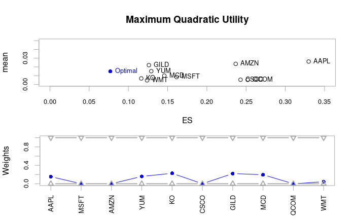

```r
plot(opt_qu, chart.assets=TRUE, main="Maximum Quadratic Utility",
      xlim=c(0, 0.35), ylim=c(0,0.05))
```

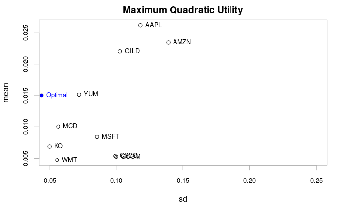

```r
chart.RiskReward(opt_qu,return.col="mean", risk.col="sd",
                 chart.assets=TRUE,
                 xlim=c(0.05, 0.25),
                 main="Maximum Quadratic Utility")
```

Backtesting: Quarterly rebalancing with 5 year training period

```r
bt_qu <- optimize.portfolio.rebalancing(R=stocks.returns.xts, portfolio=portf_maxqua,
                                        objectives=qu_obj,
                                        optimize_method="ROI",
                                        rebalance_on="quarters",
                                        training_period=60)
```

[output not shown]

```r
bt_qu2 <- optimize.portfolio.rebalancing(R=stocks.returns.xts, portfolio=portf_maxqua,
                                        objectives=qu_obj,
                                        optimize_method="ROI",
                                        rebalance_on="quarters",
                                        training_period=60,
                                        rolling_window = 48)
```

[output not shown]

### With risk aversion = 5

Create risk aversion objective and combine with return objective

```r
var_obj2 <- portfolio_risk_objective(name="var", risk_aversion=5)

qu_obj2 <- list(ret_obj, var_obj2)

qu_obj2
```

```
[[1]]
$name
[1] "mean"

$target
NULL

$arguments
list()

$enabled
[1] TRUE

$multiplier
[1] -1

attr(,"class")
[1] "return_objective" "objective"

[[2]]
$name
[1] "var"

$target
NULL

$arguments
$arguments$portfolio_method
[1] "single"


$enabled
[1] TRUE

$multiplier
[1] 1

$risk_aversion
[1] 5

attr(,"class")
[1] "portfolio_risk_objective" "objective"
```

Run the optimization

```r
opt_qu2 <- optimize.portfolio(R=stocks.returns.xts, portfolio=portf_maxqua,
                             objectives=qu_obj2,
                             optimize_method="ROI",
                             trace=TRUE)
```

[output not shown]

```r
plot(opt_qu2, chart.assets=TRUE, main="Maximum Quadratic Utility",
      xlim=c(0, 0.35), ylim=c(0,0.05))
```

[output not shown]

```r
chart.RiskReward(opt_qu2,return.col="mean", risk.col="sd",
                 chart.assets=TRUE,
                 xlim=c(0.05, 0.25),
                 main="Maximum Quadratic Utility")
```

[output not shown]

Backtesting: Quarterly rebalancing with 5 year training period

```r
bt_qu3 <- optimize.portfolio.rebalancing(R=stocks.returns.xts, portfolio=portf_maxqua,
                                        objectives=qu_obj2,
                                        optimize_method="ROI",
                                        rebalance_on="quarters",
                                        training_period=60)
```

[output not shown]

```r
bt_qu4 <- optimize.portfolio.rebalancing(R=stocks.returns.xts, portfolio=portf_maxqua,
                                        objectives=qu_obj2,
                                        optimize_method="ROI",
                                        rebalance_on="quarters",
                                        training_period=60,
                                        rolling_window = 48)
```

[output not shown]

checking for a variety of constraints (constraints that can be computed with the `ROI`-solver) and different rebalancing periods (as well as rolling windows/training periods) to find, what might deliver you the best portfolios performance (use appropriate statistics to decide on that).

```r
wts_maxret <- c(0, 0, 0, 1, 0, 0, 0, 0, 0, 0)
wts_minvar <- c(0.0344, 0.0821, 0, 0, 0.006, 0, 0.2965, 0.0021, 0.5143, 0.0645)
wts_qu <- c(0.5127, 0, 0.1358, 0.1965, 0.0693, 0, 0.0857, 0, 0, 0)
wts_qu2 <- c(0.1738, 0.0173, 0.0047, 0.0217, 0.0706, 0, 0.3064, 0, 0.4055, 0)

wts_maxret
```

```
 [1] 0 0 0 1 0 0 0 0 0 0
```

```r
wts_minvar
```

```
 [1] 0.0344 0.0821 0.0000 0.0000 0.0060 0.0000 0.2965 0.0021 0.5143 0.0645
```

```r
wts_qu
```

```
 [1] 0.5127 0.0000 0.1358 0.1965 0.0693 0.0000 0.0857 0.0000 0.0000 0.0000
```

```r
wts_qu2
```

```
 [1] 0.1738 0.0173 0.0047 0.0217 0.0706 0.0000 0.3064 0.0000 0.4055 0.0000
```

```r
stocks.returns
```

[output not shown]

Baseline Returns S&P 500

```r
baseline.returns <- "^GSPC" %>%
    tq_get(get  = "stock.prices",
           from = "2000-01-01",
           to   = "2019-12-31") %>%
    tq_transmute(select     = adjusted,
                 mutate_fun = periodReturn,
                 period     = "monthly",
                 col_rename = "Rb")

baseline.returns
```

| date | Rb |
| --- | --- |
| 2000-01-31 | -0.041753145 |
| 2000-02-29 | -0.020108083 |
| 2000-03-31 | 0.096719828 |
| 2000-04-28 | -0.030795756 |
| 2000-05-31 | -0.021915051 |
| 2000-06-30 | 0.023933550 |
| 2000-07-31 | -0.016341276 |
| 2000-08-31 | 0.060699105 |
| 2000-09-29 | -0.053482975 |
| 2000-10-31 | -0.004949486 |

[output cut: 50 more lines]

Merging the datasets together to compute CAPM

```r
RaRb.maxret <- left_join(portfolio.returns.maxret,
                                   baseline.returns,
                                   by = "date")
```

[output not shown]

CAPM MaxRet Portfolio

```r
RaRb.maxret %>%
    tq_performance(Ra = Ra, Rb = Rb,
    performance_fun = table.CAPM)
```

[output not shown]

CAPM MinVar Portfolio

```r
RaRb.minvar %>%
    tq_performance(Ra = Ra, Rb = Rb,
    performance_fun = table.CAPM)
```

[output not shown]

CAPM Quadratic Utility Portfolio risk_aversion=1

```r
RaRb.qu %>%
    tq_performance(Ra = Ra, Rb = Rb,
    performance_fun = table.CAPM)
```

[output not shown]

CAPM Quadratic Utility Portfolio risk_aversion=5

```r
RaRb.qu2 %>%
    tq_performance(Ra = Ra, Rb = Rb,
    performance_fun = table.CAPM)
```

[output not shown]

```r
portfolio.returns.maxret %>%
    ggplot(aes(x = date, y = Ra)) +
    geom_bar(stat = "identity", fill = palette_light()[[1]]) +
    labs(title = "MaxRet Portfolio Returns",
         x = "", y = "Monthly Returns") +
    geom_smooth(method = "lm") +
    theme_tq() +
    scale_color_tq() +
    scale_y_continuous(labels = scales::percent)
```

[output not shown]

```r
portfolio.returns.minvar %>%
    ggplot(aes(x = date, y = Ra)) +
    geom_bar(stat = "identity", fill = palette_light()[[1]]) +
    labs(title = "MinVar Portfolio Returns",
         x = "", y = "Monthly Returns") +
    geom_smooth(method = "lm") +
    theme_tq() +
    scale_color_tq() +
    scale_y_continuous(labels = scales::percent)
```

[output not shown]

```r
portfolio.returns.qu %>%
    ggplot(aes(x = date, y = Ra)) +
    geom_bar(stat = "identity", fill = palette_light()[[1]]) +
    labs(title = "Quadratic Utility Portfolio Returns (Riskaversion=1)",
         x = "", y = "Monthly Returns") +
    geom_smooth(method = "lm") +
    theme_tq() +
    scale_color_tq() +
    scale_y_continuous(labels = scales::percent)
```

[output not shown]

```r
portfolio.returns.qu2 %>%
    ggplot(aes(x = date, y = Ra)) +
    geom_bar(stat = "identity", fill = palette_light()[[1]]) +
    labs(title = "Quadratic Utility Portfolio Returns (Riskaversion=5)",
         x = "", y = "Monthly Returns") +
    geom_smooth(method = "lm") +
    theme_tq() +
    scale_color_tq() +
    scale_y_continuous(labels = scales::percent)
```

[output not shown]